# Lab 4 - Linear Regression

Natasha Ting

This assignment is based on the material covered in James et al. We will subsequently open up solutions to the problem sets.

## Exercise 4.1

This question involves the use of multiple linear regression on the `Auto` data set. So load the data set from the `ISLR` package first.

If the following code chunk returns an error, you most likely have to install the `ISLR` package first. Use `install.packages("ISLR")` if this is the case.

```r
# install.packages("ISLR")
data("Auto", package = "ISLR")

#

# !! `auto <- try(data(Auto, package="ISLR")` doesn't work. Can't assign a dataset to a variable.
```

1. Produce a scatterplot matrix which includes all of the variables in the data set.

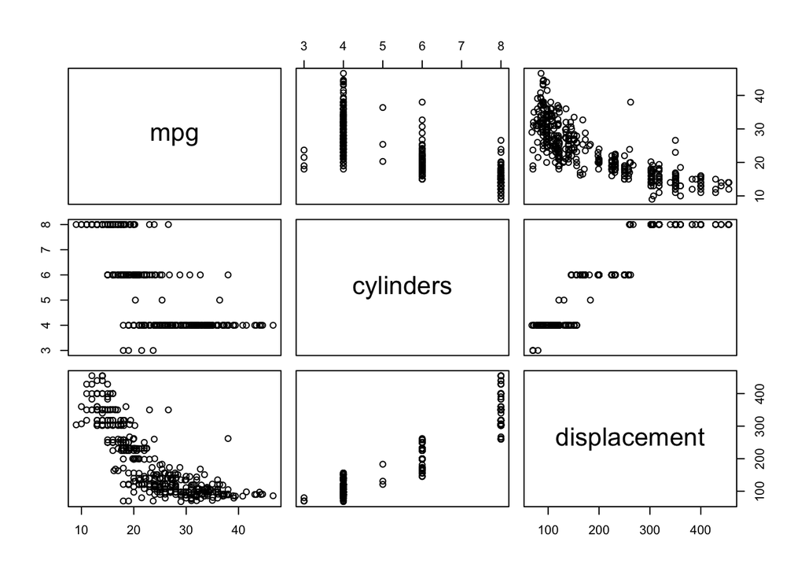

```r
par(mfrow=c(4,3))
pairs(Auto[1:3])
```

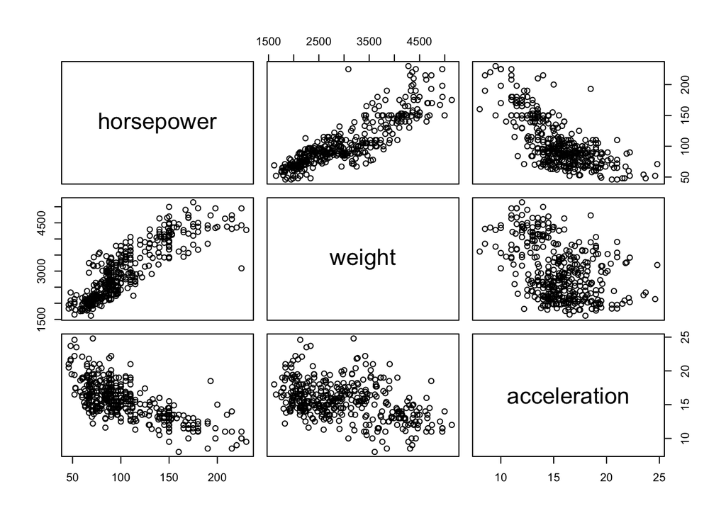

```r
pairs(Auto[4:6])
```

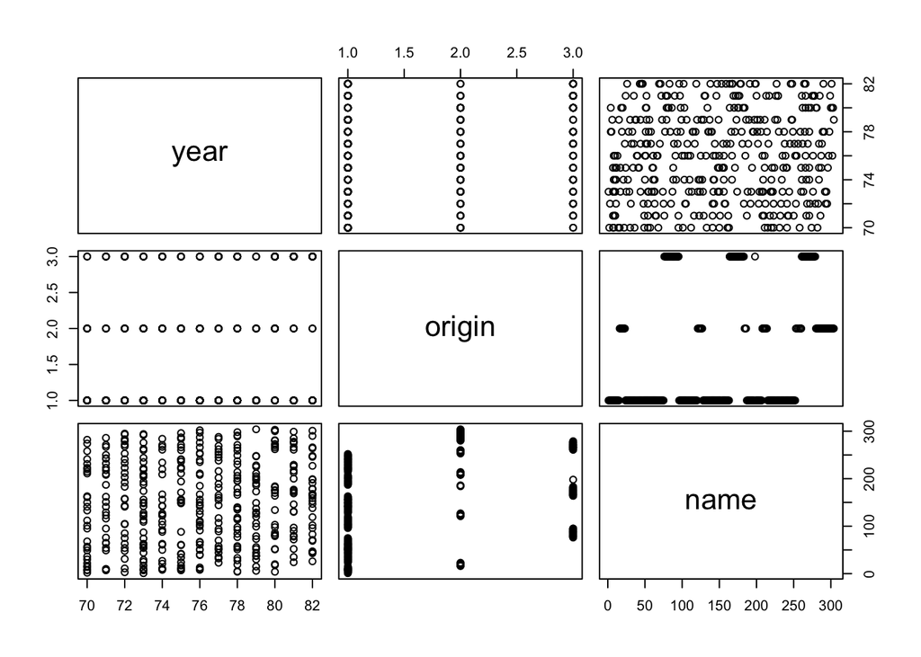

```r
pairs(Auto[7:9])
```

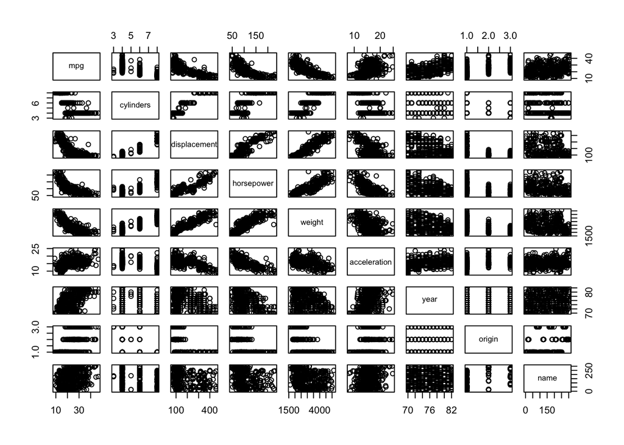

```r
plot(Auto)
```

2. Compute the matrix of correlations between the variables using the function `cor()`. You will need to exclude the `name` variable, which is qualitative.

```r
library(dplyr)
# can subset whith col number
print(which(colnames(Auto)=="name") )
```

```
## [1] 9
```

```r
Auto1 <- Auto[c(-9)]

# can subset with names
Auto2 <- Auto[c(-which(colnames(Auto)=="name"))]

# can subset with subset
Auto3 <- subset(Auto, select = !colnames(Auto) %in% "name")

# fail to  subset with filter
# `Auto4 <- Auto %>% dplyr::filter(UQ(!!as.name("name")=="name")))`

# can subset with select_if
Auto4 <- Auto %>% select_if(is.numeric)

# check if 2 dfs are equal
identical(Auto1, Auto2)
```

```
## [1] TRUE
```

```r
# another method to check if 2 dfs are equal
isTRUE(all.equal(Auto2, Auto3))
```

```
## [1] TRUE
```

```r
all.equal(Auto2, Auto3)
```

```
## [1] TRUE
```

3. Use the `lm()` function to perform a multiple linear regression with `mpg` as the response and all other variables except `name` as the predictors. Use the `summary()` function to print the results. Comment on the output. For instance:
   1. Is there a relationship between the predictors and the response?
   2. Which predictors appear to have a statistically significant relationship to the response?
   3. What does the coefficient for the `year` variable suggest?

```r
# another way to reg on all var --- `myregreg <- with(Auto1, lm(mpg~., data = Auto1))`
myreg = lm(mpg ~ ., data=Auto1)
summary(myreg)
```

```
##
## Call:
## lm(formula = mpg ~ ., data = Auto1)
##
## Residuals:
##     Min      1Q  Median      3Q     Max
## -9.5903 -2.1565 -0.1169  1.8690 13.0604
##
## Coefficients:
##                Estimate Std. Error t value Pr(>|t|)
## (Intercept)  -17.218435   4.644294  -3.707  0.00024 ***
## cylinders     -0.493376   0.323282  -1.526  0.12780
## displacement   0.019896   0.007515   2.647  0.00844 **
## horsepower    -0.016951   0.013787  -1.230  0.21963
## weight        -0.006474   0.000652  -9.929  < 2e-16 ***
## acceleration   0.080576   0.098845   0.815  0.41548
## year           0.750773   0.050973  14.729  < 2e-16 ***
## origin         1.426141   0.278136   5.127 4.67e-07 ***
## ---
## Signif. codes:  0 '***' 0.001 '**' 0.01 '*' 0.05 '.' 0.1 ' ' 1
##
## Residual standard error: 3.328 on 384 degrees of freedom
## Multiple R-squared:  0.8215, Adjusted R-squared:  0.8182
## F-statistic: 252.4 on 7 and 384 DF,  p-value: < 2.2e-16
```

4. Use the `plot()` function to produce diagnostic plots of the linear regression fit. Comment on any problems you see with the fit. Do the residual plots suggest any unusually large outliers? Does the leverage plot identify any observations with unusually high leverage?

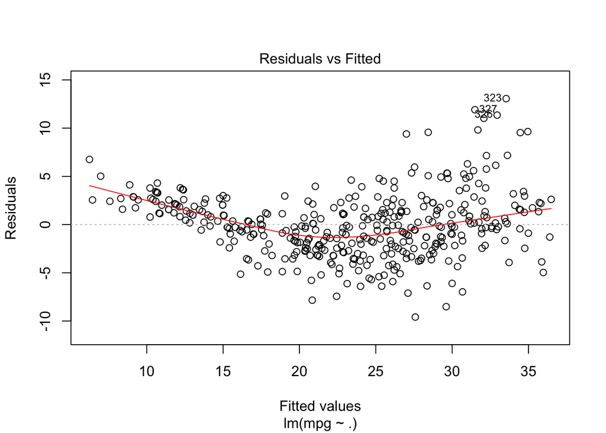

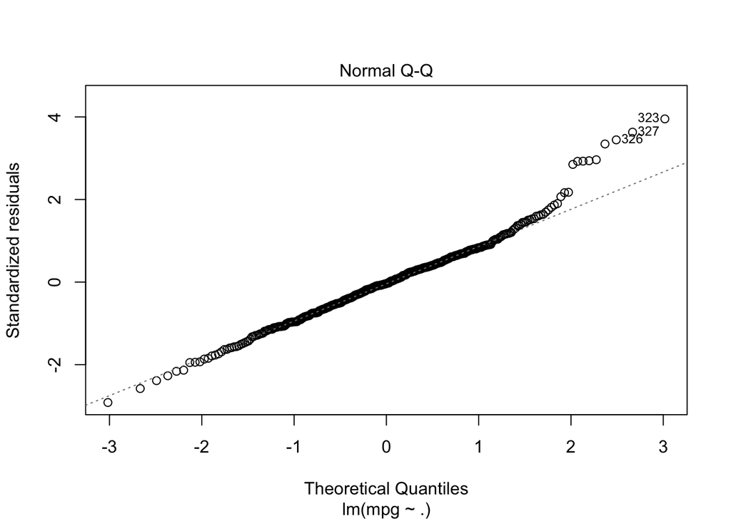

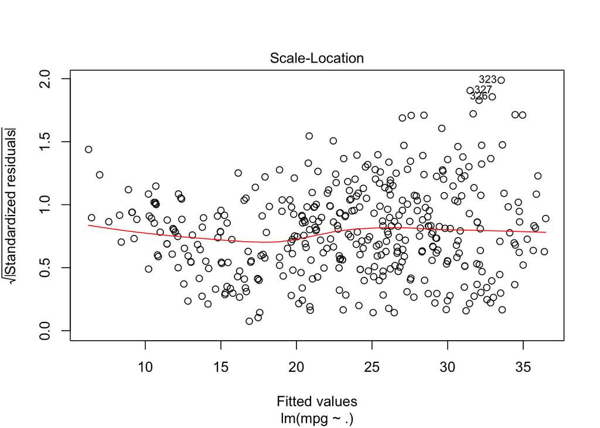

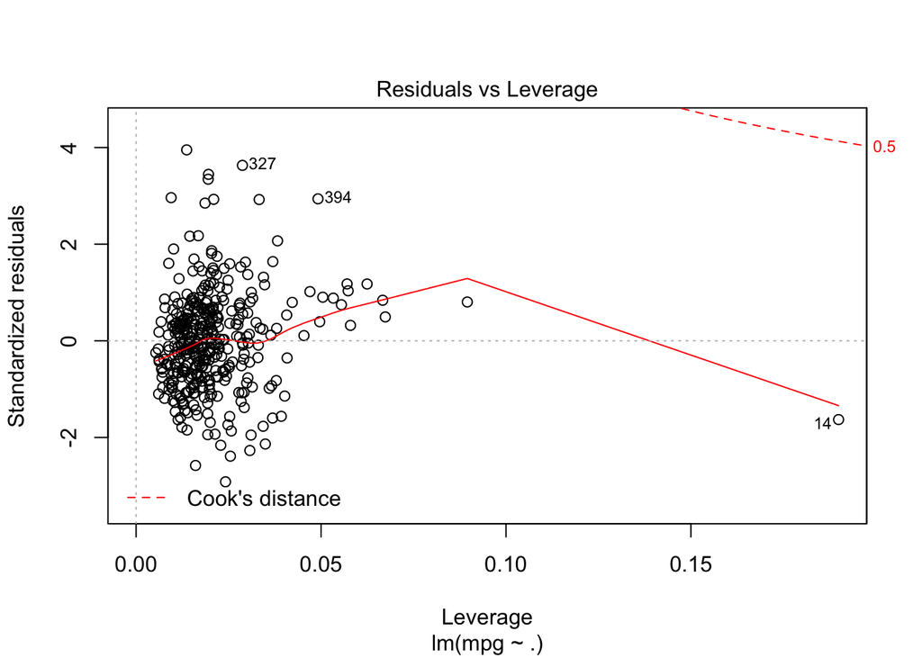

```r
# do the plot
plot(myreg)
```

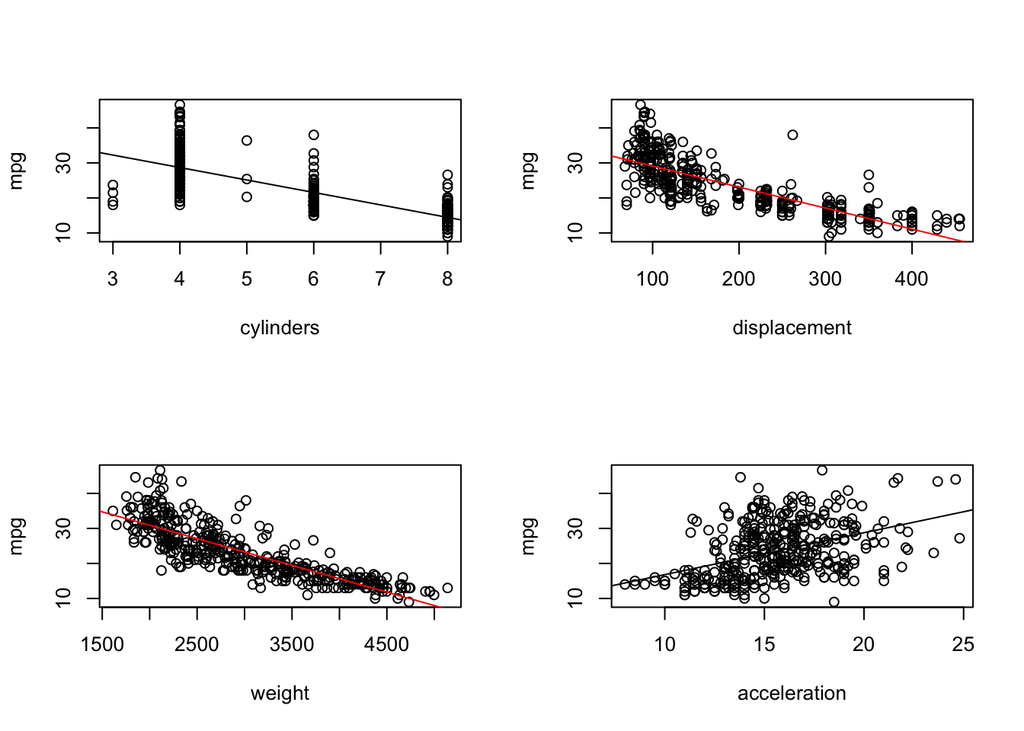

```r
par(mfrow=c(2,2))
with(Auto1, plot(cylinders, mpg))
abline(lm(mpg~cylinders, Auto1))

with(Auto1, plot(displacement, mpg))
abline(lm(mpg~displacement, Auto1), col="red")

with(Auto1, plot(weight, mpg))
abline(lm(mpg~weight, Auto1), col="red")

# intercept: -17.218435
# slope for acceleration : 0.080576
with(Auto1, plot(acceleration, mpg))
abline(lm(mpg~acceleration, Auto1))
```

```r
# this snippet shows that the lines for SLR and MLR on the same variables are not the same.
par(mfrow=c(2,2))
with(Auto1, plot(acceleration, mpg))
abline(lm(mpg~acceleration, Auto1))

coefficients(myreg)
```

```
##   (Intercept)     cylinders  displacement    horsepower        weight
## -17.218434622  -0.493376319   0.019895644  -0.016951144  -0.006474043
##  acceleration          year        origin
##   0.080575838   0.750772678   1.426140495
```

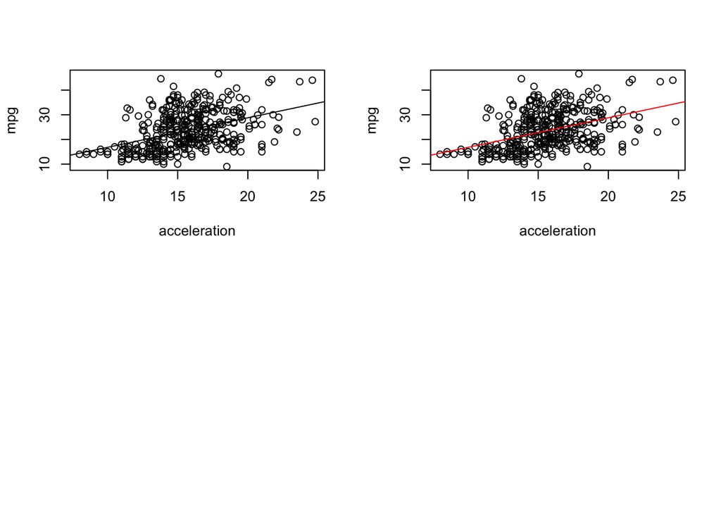

```r
with(Auto1, plot(acceleration, mpg))
abline(as.numeric(myreg$coefficients[1]), as.numeric(myreg$coefficients[6]), col="blue")
abline(lm(mpg ~ acceleration, Auto1), col="red")
```

```r
colnames(Auto1)
```

```
## [1] "mpg"          "cylinders"    "displacement" "horsepower"
## [5] "weight"       "acceleration" "year"         "origin"
```

```r
par(mfrow=c(2,1))
with(Auto1, plot(year, mpg))
abline(lm(mpg~year, Auto1))

summary(lm(mpg~year, Auto1))
```

```
##
## Call:
## lm(formula = mpg ~ year, data = Auto1)
##
## Residuals:
##      Min       1Q   Median       3Q      Max
## -12.0212  -5.4411  -0.4412   4.9739  18.2088
##
## Coefficients:
##              Estimate Std. Error t value Pr(>|t|)
## (Intercept) -70.01167    6.64516  -10.54   <2e-16 ***
## year          1.23004    0.08736   14.08   <2e-16 ***
## ---
## Signif. codes:  0 '***' 0.001 '**' 0.01 '*' 0.05 '.' 0.1 ' ' 1
##
## Residual standard error: 6.363 on 390 degrees of freedom
## Multiple R-squared:  0.337,  Adjusted R-squared:  0.3353
## F-statistic: 198.3 on 1 and 390 DF,  p-value: < 2.2e-16
```

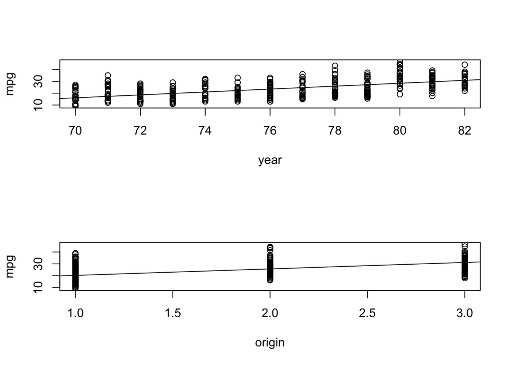

```r
with(Auto1, plot(origin, mpg))
abline(lm(mpg~origin, Auto1))
```

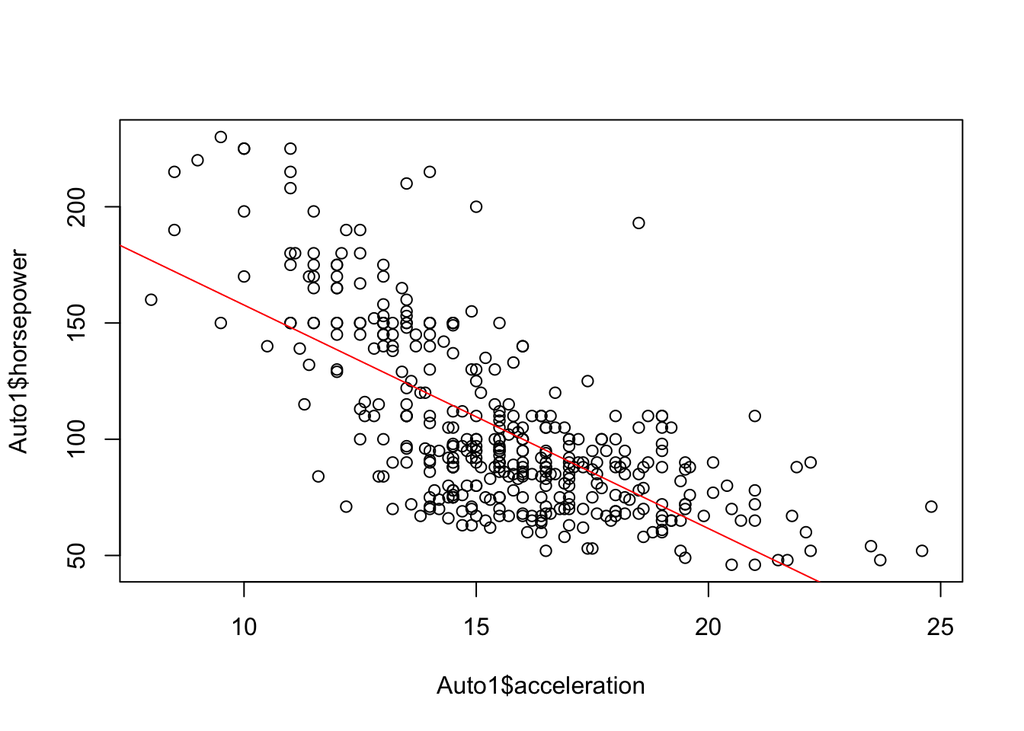

```r
horse_acceleration <- Auto1$horsepower * Auto1$acceleration
plot(Auto1$acceleration, Auto1$horsepower)
abline(lm(horsepower~acceleration, Auto1), col="red")
```

```r
sprintf("It seems that horsepower and accelaration has high negative correlation of %f, with a fitted prodictor value of %f ",cor(Auto1$horsepower, Auto1$acceleration), coef(lm(horsepower~acceleration, Auto1))[2])
```

```
## [1] "It seems that horsepower and accelaration has high negative correlation of -0.689196, with a fitted prodictor value of -9.615528 "
```

```r
Autoplus <- Auto1 %>% dplyr::mutate(horsepower * acceleration)
# go, go ahead with regressing on that
lm.interact <-lm(mpg ~ ., data=Autoplus)
summary(lm.interact)
```

```
##
## Call:
## lm(formula = mpg ~ ., data = Autoplus)
##
## Residuals:
##     Min      1Q  Median      3Q     Max
## -9.0329 -1.8177 -0.1183  1.7247 12.4870
##
## Coefficients:
##                               Estimate Std. Error t value Pr(>|t|)
## (Intercept)                 -32.499820   4.923380  -6.601 1.36e-10 ***
## cylinders                     0.083489   0.316913   0.263 0.792350
## displacement                 -0.007649   0.008161  -0.937 0.349244
## horsepower                    0.127188   0.024746   5.140 4.40e-07 ***
## weight                       -0.003976   0.000716  -5.552 5.27e-08 ***
## acceleration                  0.983282   0.161513   6.088 2.78e-09 ***
## year                          0.755919   0.048179  15.690  < 2e-16 ***
## origin                        1.035733   0.268962   3.851 0.000138 ***
## `horsepower * acceleration`  -0.012139   0.001772  -6.851 2.93e-11 ***
## ---
## Signif. codes:  0 '***' 0.001 '**' 0.01 '*' 0.05 '.' 0.1 ' ' 1
##
## Residual standard error: 3.145 on 383 degrees of freedom
## Multiple R-squared:  0.841,  Adjusted R-squared:  0.8376
## F-statistic: 253.2 on 8 and 383 DF,  p-value: < 2.2e-16
```

**I note that the interaction term is highly statistically significant. In addition, adjusted r-squared has gone up from 0.8182238 to 0.8376468**

```r
sprintf("I note that the interaction term is highly statistically significant. In addition, adjusted r-squared has gone up from %f to %f", summary(myreg)$adj.r.squared, summary(lm.interact)$adj.r.squared)
```

```
## [1] "I note that the interaction term is highly statistically significant. In addition, adjusted r-squared has gone up from 0.818224 to 0.837647"
```

6. Try a few different transformations of the variables, such as $log(X)$, $\sqrt{X}$, $X^2$. Comment on your findings.

```r
lm.horse <- lm(mpg~horsepower, data=Auto1)
summary(lm.horse)$r.squared
```

```
## [1] 0.6059483
```

```r
lm.log_horse <- lm(mpg~log(horsepower), data=Auto1)
summary(lm.log_horse)$r.squared
```

```
## [1] 0.6683348
```

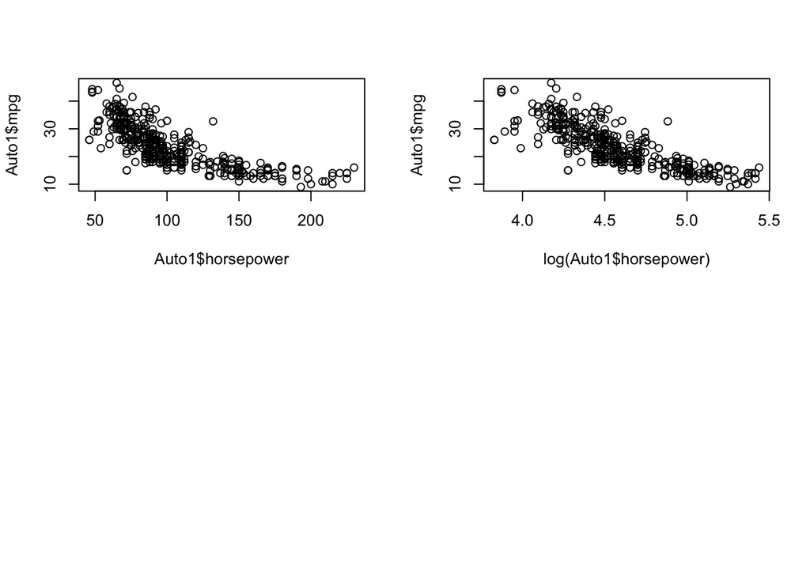

```r
par(mfrow = c(2,2))
plot(Auto1$horsepower, Auto1$mpg)
plot(log(Auto1$horsepower), Auto1$mpg)
```

## Exercise 4.2

This question should be answered using the `Carseats` dataset from the `ISLR` package. So load the data set from the `ISLR` package first.

```r
data("Carseats", package = "ISLR")
# colnames(select_if(Carseats,is.numeric))
# [1] "Sales"       "CompPrice"   "Income"      "Advertising" "Population"
# [6] "Price"       "Age"         "Education"
```

1. Fit a multiple regression model to predict `Sales` using `Price`, `Urban`, and `US`.

```r
attach(Carseats)
lm.1 <- lm(Sales ~ Price + Urban + US)
summary(lm.1)
```

```
##
## Call:
## lm(formula = Sales ~ Price + Urban + US)
##
## Residuals:
##     Min      1Q  Median      3Q     Max
## -6.9206 -1.6220 -0.0564  1.5786  7.0581
##
## Coefficients:
##              Estimate Std. Error t value Pr(>|t|)
## (Intercept) 13.043469   0.651012  20.036  < 2e-16 ***
## Price       -0.054459   0.005242 -10.389  < 2e-16 ***
## UrbanYes    -0.021916   0.271650  -0.081    0.936
## USYes        1.200573   0.259042   4.635 4.86e-06 ***
## ---
## Signif. codes:  0 '***' 0.001 '**' 0.01 '*' 0.05 '.' 0.1 ' ' 1
##
## Residual standard error: 2.472 on 396 degrees of freedom
## Multiple R-squared:  0.2393, Adjusted R-squared:  0.2335
## F-statistic: 41.52 on 3 and 396 DF,  p-value: < 2.2e-16
```

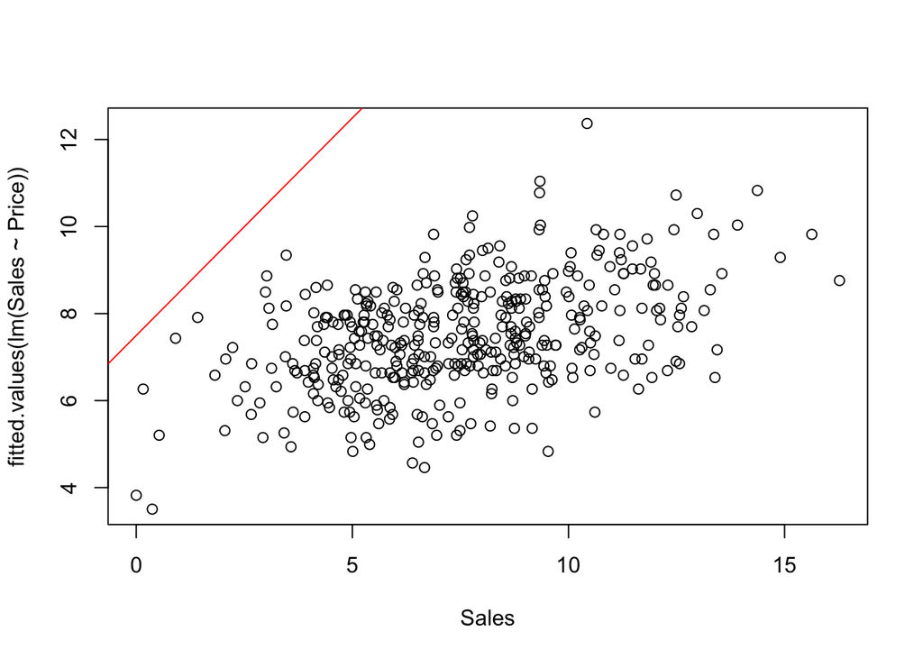

```r
# plot something
plot(Sales, fitted.values(lm(Sales~Price)))
abline(lm(Sales~Price), col="blue")
abline(lm(Sales~residuals(lm(Sales~Price))), col="red")
```

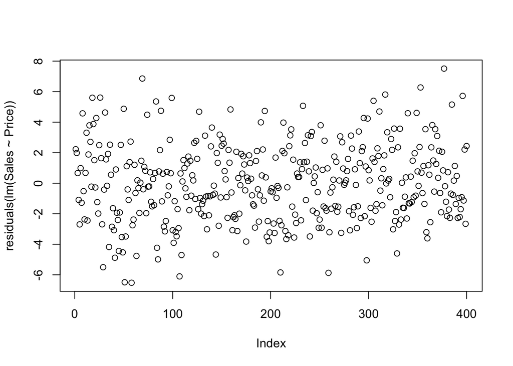

```r
# data satisfies homogeneity assumption
plot(residuals(lm(Sales~Price)))
```

2. Provide an interpretation of each coefficient in the model. Be careful – some of the variables in the model are qualitative!

```r
is.numeric(c(US, Price, Sales, Urban))
```

```
## [1] TRUE
```

```r
# import script to use my own function
source("myfunctions.R")
sapply(c(1:length(colnames(lm.1$model))), describe_coef, regression=lm.1)
```

```
## [1] "Intercept of model is 13.043469"
## [2] "Coefficient 'Price' has a slope of -0.054459. It is a character variable. "
## [3] "Coefficient 'Urban' has a slope of -0.021916. It is a character variable. "
## [4] "Coefficient 'US' has a slope of 1.200573. It is a character variable. "
```

**For every 1 dollar increase in price, given the same car type (urban or not) and car origing (U.S. made or not), sales decreases by 0.05 units. Sales for urban cars is less than the non-urban ones by 0.02 units holding car type and car price constant. In addition, U.S. made cars sell better, with a sales performance of 1.2 units more than the non-U.S. made models.**

```r
lm.small <- lm(Sales ~ Price + US)
summary(lm.small)
```

```
##
## Call:
## lm(formula = Sales ~ Price + US)
##
## Residuals:
##     Min      1Q  Median      3Q     Max
## -6.9269 -1.6286 -0.0574  1.5766  7.0515
##
## Coefficients:
##             Estimate Std. Error t value Pr(>|t|)
## (Intercept) 13.03079    0.63098  20.652  < 2e-16 ***
## Price       -0.05448    0.00523 -10.416  < 2e-16 ***
## USYes        1.19964    0.25846   4.641 4.71e-06 ***
## ---
## Signif. codes:  0 '***' 0.001 '**' 0.01 '*' 0.05 '.' 0.1 ' ' 1
##
## Residual standard error: 2.469 on 397 degrees of freedom
## Multiple R-squared:  0.2393, Adjusted R-squared:  0.2354
## F-statistic: 62.43 on 2 and 397 DF,  p-value: < 2.2e-16
```

6. How well do the models in (a) and (e) fit the data?

```r
sprintf("R-squared for this model is %s, the model can explain %s percent of variation in Sales. ", summary(lm.small)$r.squared, round(x = summary(lm.small)$r.squared*100, digits = 2))
```

```
## [1] "R-squared for this model is 0.239262888426786, the model can explain 23.93 percent of variation in Sales. "
```

7. Using the model from (e), obtain 95% confidence intervals for the coefficient(s).

```r
confint(object = lm.small, level = 0.95)
```

```
##                   2.5 %      97.5 %
## (Intercept) 11.79032020 14.27126531
## Price       -0.06475984 -0.04419543
## USYes        0.69151957  1.70776632
```

**From the data, it can be said that the true effect of price on car sales will be within -0.0648 and -0.0442, 95% of the time, if the linear regression is performed on an infinite number of sample data. The true effect of the car being U.S. made is within 0.6915 and 1.7078 given the same conditions.**

8. Is there evidence of outliers or high leverage observations in the model from (e)?

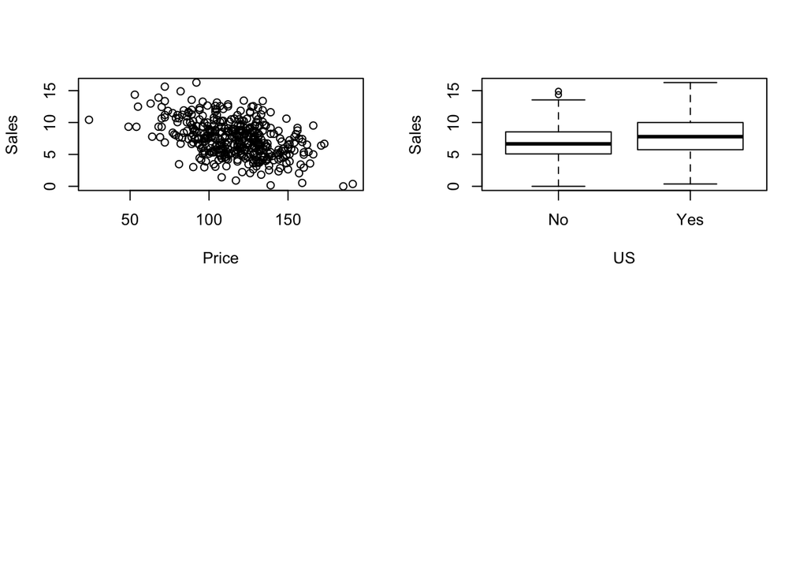

```r
par(mfrow=c(2,2))
plot(Price, Sales)
plot(US, Sales, xlab = "US", ylab="Sales")
```

**The graphs provide graphical evidence that there are outliers in both Price and US variables.**

## Exercise 4.3 (Optional)

In this exercise you will create some simulated data and will fit simple linear regression models to it. Make sure to use `set.seed(1)` prior to starting part (a) to ensure consistent results.

1. Using the `rnorm()` function, create a vector, `x`, containing 100 observations drawn from a $N(0,1)$ distribution. This represents a feature, `X`.

```r
set.seed(1)
```

2. Using the `rnorm()` function, create a vector, `eps`, containing 100 observations drawn from a $N(0,0.25)$ distribution i.e. a normal distribution with mean zero and variance 0.25.
3. Using `x` and `eps`, generate a vector `y` according to the model
   $$Y = -1 + 0.5X + \epsilon$$
   What is the length of the vector `y`? What are the values of $\beta_0$ and $\beta_1$ in this linear model?
4. Create a scatterplot displaying the relationship between `x` and `y`. Comment on what you observe.
5. Fit a least squares linear model to predict `y` using `x`. Comment on the model obtained. How do $\hat{\beta}_0$ and $\hat{\beta}_1$ compare to $\beta_0$ and $\beta_1$?
6. Display the least squares line on the scatterplot obtained in (d). Draw the population regression line on the plot, in a different color. Use the `legend()` command to create an appropriate legend.
7. Now fit a polynomial regression model that predicts $y$ using $x$ and $x^2$. Is there evidence that the quadratic term improves the model fit? Explain your answer.
8. Repeat (a)-(f) after modifying the data generation process in such a way that there is less noise in the data. The model should remain the same. You can do this by decreasing the variance of the normal distribution used to generate the error term $\epsilon$ in (b). Describe your results.
9. Repeat (a)-(f) after modifying the data generation process in such a way that there is more noise in the data. The model should remain the same. You can do this by increasing the variance of the normal distribution used to generate the error term $\epsilon$ in (b). Describe your results.
10. What are the confidence intervals for $\beta_0$ and $\beta_1$ based on the original data set, the noisier data set, and the less noisy data set? Comment on your results.